# MATH1307 Forecasting Assignment 1

**Crude Oil Price**

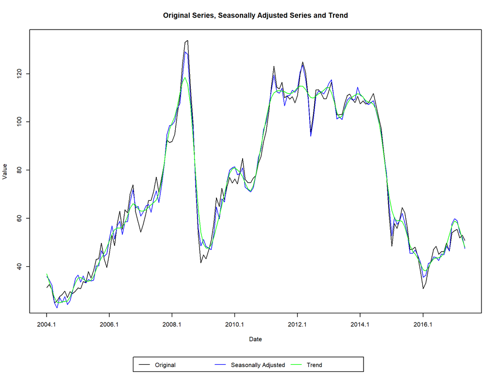

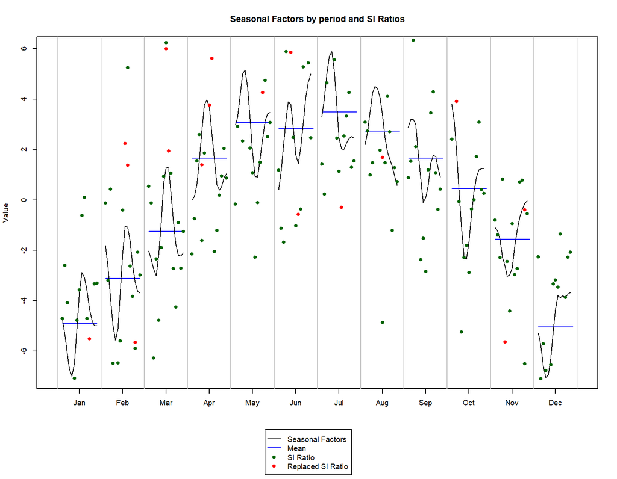

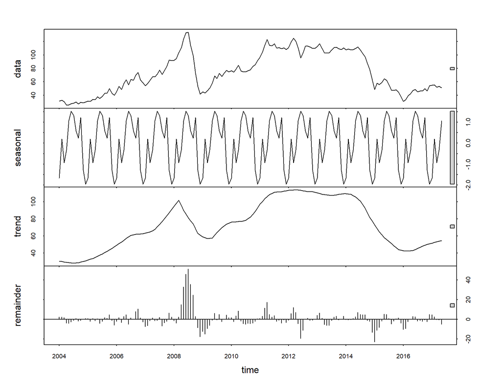

```r
decom(oil_TS)
```

From x12 graph, it is observed that seasonaly adjusted series is mostly overlapping the original series, while the trend has marginal deviation from original.

The adjusted seasonal factors are diverted and not following the seasonal pattern around mean for any month. Infect, there are extreme outliers in the month of february, march, august and september.

STL graph depicts that, trend follows the original pattern with continious upward trend till 2008, then intervention point occurs due to some external factors, which can be confirmed by spike in remainder part for the same time period . Since there is no indication of seasonality in the ACF and visualisation plot, seasonality in STL is not meaningful.

**Copper Price**

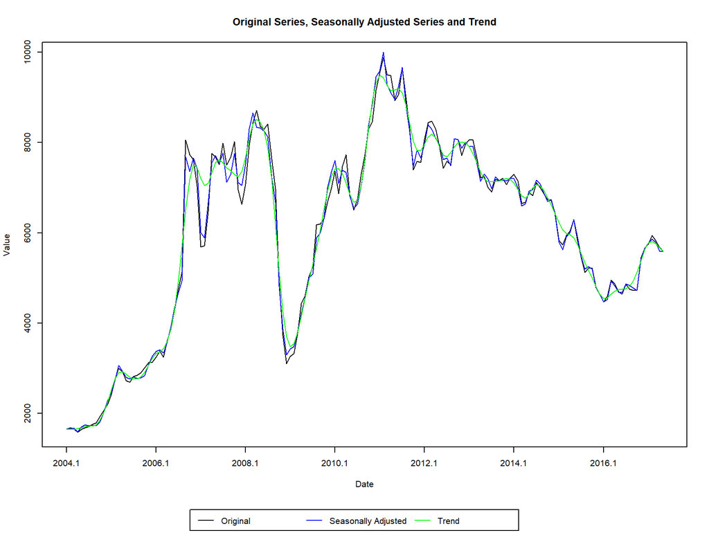

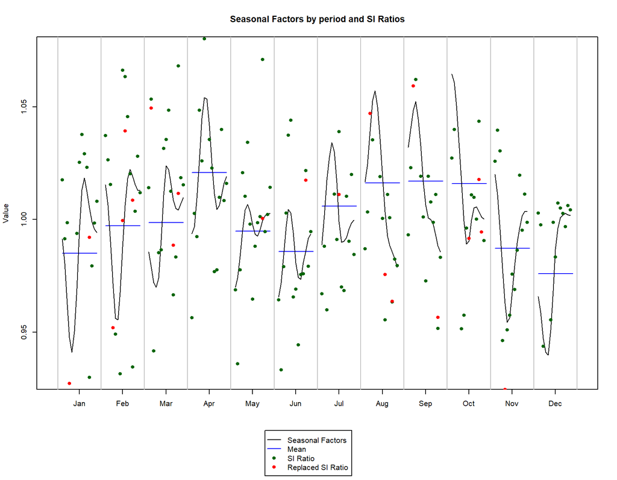

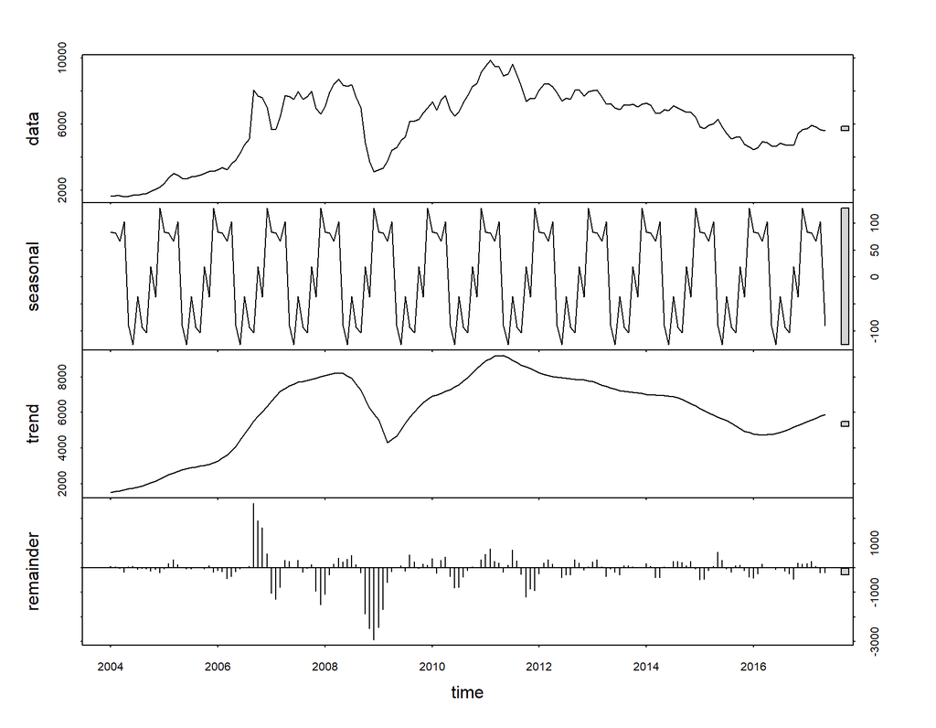

```r
decom(copper_TS)
```

From x12 graph, it is observed that seasonaly adjusted series is mostly overlapping the original series, while the trend has marginal deviation from original.

# **3.The most accurate and suitable distributed lag model**

**Scaled Graph**

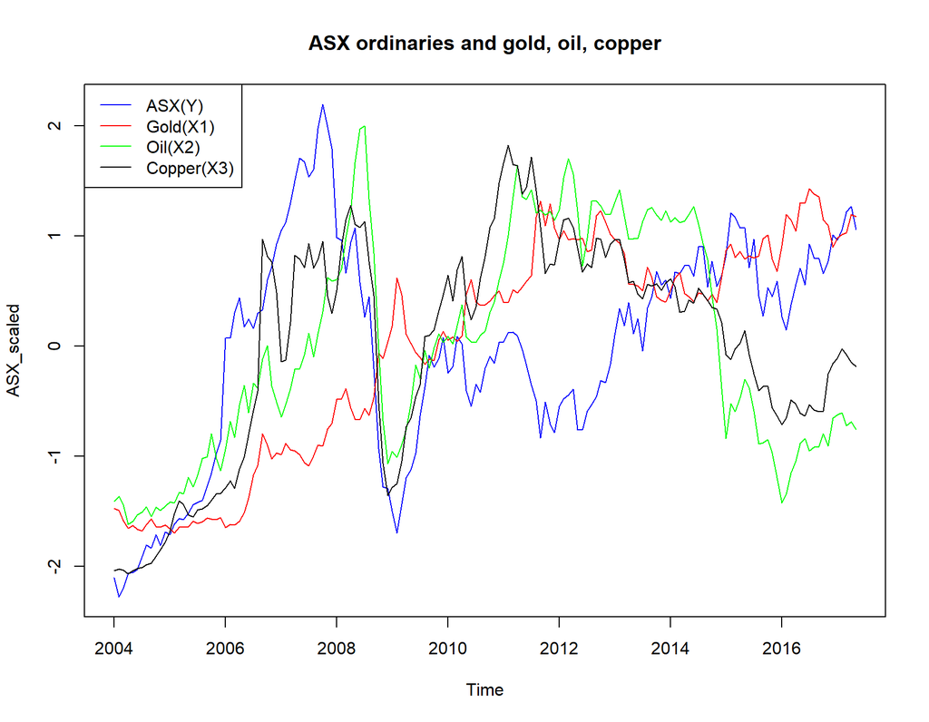

```r
ASX_scaled= scale(ASX_data_TS)
plot(ASX_scaled, plot.type="s",
     col =  c("blue", "red","green","black"),
     main= "ASX ordinaries and gold, oil, copper")
legend("topleft",lty=1,col=c("blue","red","green","black"), c("ASX(Y)", "Gold(X1)","Oil(X2)","Copper(X3)"))
```

```r
cor <- as.data.frame(cor(ASX_data_TS)) %>% round(3)
kbl(cor) %>%
  kable_paper()
```

|  | ASX price | Gold price | Crude Oil (Brent)_USD/bbl | Copper_USD/tonne |
| --- | --- | --- | --- | --- |
| ASX price | 1.000 | 0.343 | 0.329 | 0.562 |
| Gold price | 0.343 | 1.000 | 0.437 | 0.536 |
| Crude Oil (Brent)_USD/bbl | 0.329 | 0.437 | 1.000 | 0.866 |
| Copper_USD/tonne | 0.562 | 0.536 | 0.866 | 1.000 |

Above scaled graph gives idea about which independent time series object(X1,X2,X3) closly followed by independent time series object(Y).

Here,

Y = ASX ords Price,

X1 = Gold Price

X2 = Crude Oil Price

X3 = Copper Price

By inspection, it is observed that, copper price contribute the most for predicting ASX ords price.

Correlation Table confirms out assumpltion as correlation between copper and ASX is 0.562 which is far better than gold-ASX(0.343) and oil-ASX(0.329)

## Model Fitting

From correlation matrix, it is observed that, crude oil and copper are highly correlated with other. Hence, it is not advisable to include both of them into model fitting, since copper price is more correlated, it will be used alongside gold price to find the most accurate and suitable distributed model for ASX ordinaries price index. So, for finite distributed lag models and autoregressive distributed lag model, formula would be **ASX ~ gold + copper**.

While, in terms of polynomial distributed lag model and Koyck model, only copper series will taken as independent series, since it has highest co-relation with dependent time series(ASX) and is more likely to explain ASX variation then others. Since,Polynomial distributed lag model and Koyck model allows only one independent series, our formula would be **ASX ~ copper**

## Finite Distributed Lag Models.

```r
ASX_m = as.data.frame(ASX_data[,c(1,2,3,4)])
colnames(ASX_m) <- c("asx", "gold", "oil", "copper")
for ( i in 1:12){
  model1.1 = dlm(formula = asx ~ gold + copper, data = data.frame(ASX_m), q = i )
  cat("q = ", i, "AIC = ", AIC(model1.1$model), "BIC = ", BIC(model1.1$model),"\n")
}
```

```
## q =  1 AIC =  2577.989 BIC =  2596.44
## q =  2 AIC =  2564.871 BIC =  2589.423
## q =  3 AIC =  2551.583 BIC =  2582.209
## q =  4 AIC =  2538.084 BIC =  2574.759
## q =  5 AIC =  2523.864 BIC =  2566.562
## q =  6 AIC =  2509.866 BIC =  2558.561
## q =  7 AIC =  2495.447 BIC =  2550.112
## q =  8 AIC =  2481.403 BIC =  2542.012
## q =  9 AIC =  2467.268 BIC =  2533.793
## q =  10 AIC =  2454.097 BIC =  2526.512
## q =  11 AIC =  2440.381 BIC =  2518.658
## q =  12 AIC =  2426.737 BIC =  2510.848
```

```r
model1 = dlm(formula = asx ~ gold + copper, data = data.frame(ASX_m), q = 12)
summary(model1$model)
```

```
##
## Call:
## lm(formula = as.formula(model.formula), data = design)
##
## Residuals:
##      Min       1Q   Median       3Q      Max
## -1207.47  -600.48    80.48   521.41  1620.51
##
## Coefficients:
##               Estimate Std. Error t value Pr(>|t|)
## (Intercept)  4.013e+03  2.698e+02  14.872   <2e-16 ***
## gold.t      -8.089e-01  1.290e+00  -0.627    0.532
## gold.1       2.345e-01  1.883e+00   0.125    0.901
## gold.2       1.681e-01  1.916e+00   0.088    0.930
## gold.3       1.664e-01  1.922e+00   0.087    0.931
## gold.4      -2.845e-01  1.910e+00  -0.149    0.882
## gold.5       3.780e-01  1.916e+00   0.197    0.844
## gold.6      -1.767e-01  1.946e+00  -0.091    0.928
## gold.7       5.962e-01  1.954e+00   0.305    0.761
## gold.8      -4.992e-01  1.932e+00  -0.258    0.797
## gold.9       1.807e-01  1.958e+00   0.092    0.927
## gold.10     -4.389e-03  1.971e+00  -0.002    0.998
## gold.11      5.442e-02  1.964e+00   0.028    0.978
## gold.12      2.967e-01  1.292e+00   0.230    0.819
## copper.t     1.306e-01  1.467e-01   0.890    0.375
## copper.1     2.777e-02  2.390e-01   0.116    0.908
## copper.2     4.097e-02  2.395e-01   0.171    0.864
## copper.3     1.752e-02  2.354e-01   0.074    0.941
## copper.4     4.280e-03  2.344e-01   0.018    0.985
## copper.5    -2.112e-02  2.379e-01  -0.089    0.929
## copper.6     3.132e-02  2.392e-01   0.131    0.896
## copper.7     2.104e-04  2.404e-01   0.001    0.999
## copper.8    -1.440e-02  2.428e-01  -0.059    0.953
## copper.9    -5.916e-02  2.445e-01  -0.242    0.809
## copper.10   -3.589e-02  2.426e-01  -0.148    0.883
## copper.11    1.175e-02  2.385e-01   0.049    0.961
## copper.12   -4.120e-02  1.510e-01  -0.273    0.785
## ---
## Signif. codes:  0 '***' 0.001 '**' 0.01 '*' 0.05 '.' 0.1 ' ' 1
##
## Residual standard error: 762.4 on 122 degrees of freedom
## Multiple R-squared:  0.1935, Adjusted R-squared:  0.02168
## F-statistic: 1.126 on 26 and 122 DF,  p-value: 0.3234
```

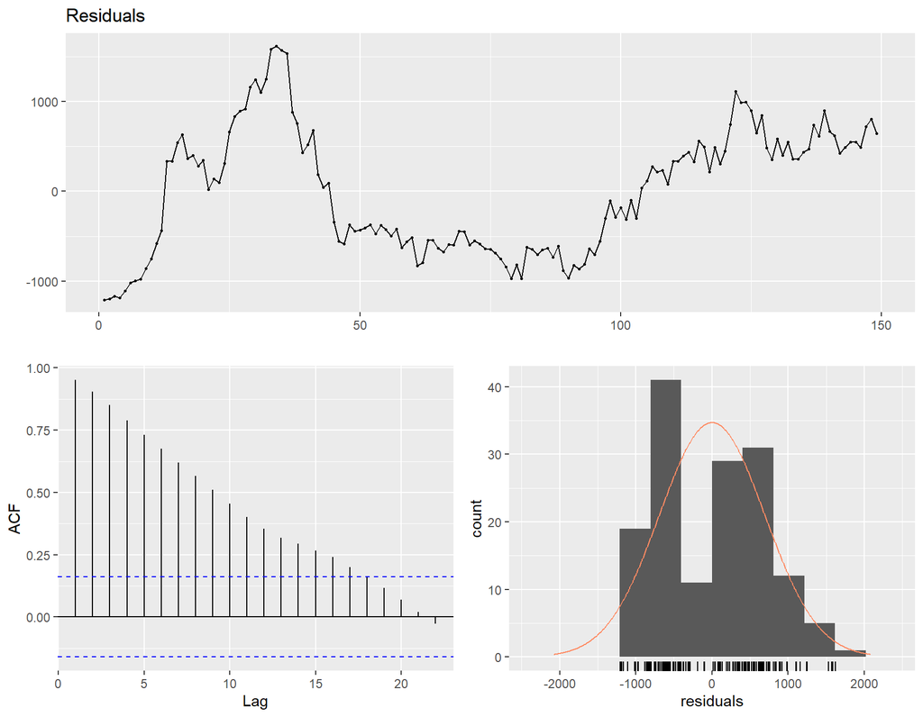

```
##
##  Breusch-Godfrey test for serial correlation of order up to 30
##
## data:  Residuals
## LM test = 138.19, df = 30, p-value = 7.96e-16
```

```r
checkresiduals(model1$model)
```

```r
vif(model1$model)
```

```
##    gold.t    gold.1    gold.2    gold.3    gold.4    gold.5    gold.6    gold.7
##  58.34747 126.11918 132.46580 135.37636 135.54139 138.29564 144.97845 147.77257
##    gold.8    gold.9   gold.10   gold.11   gold.12  copper.t  copper.1  copper.2
## 145.92043 150.61502 152.89970 151.69899  65.62082  18.38101  50.42609  52.36998
##  copper.3  copper.4  copper.5  copper.6  copper.7  copper.8  copper.9 copper.10
##  52.36940  53.81478  57.34063  59.91671  62.44331  65.51811  68.35053  69.10579
## copper.11 copper.12
##  68.56418  28.14387
```

It is observed that the both AIC and BIC values are declinig as number of lag q increases, so attempt to fit the finite model with number of lags = 12 was taken.

Summary depicts that, none of the lag-weights(co-efficients) are statistically significant at 5% level. While adjusted R squared is only 2%, even F-statistics of the model is statistically insignificant as p-value > 0.05.

Even though histogram of residuals is looking symetric, there is no random pattern in residuals, infect it looks like trend, which can be confirmed by decaying pattern in ACF. Breusch-Godfrey test supports serial correlation at 5% of statistical level.

All vif values are above 10 indicating there is high multicollinearity in model.

Hence, model is not a good fit for the given data and can not be further investigated.

## Polynomial Distributed Lag Model

The multicollinearity problem in finite DLM can be handled by polynomial DLM, as polynomial curves will be used to restrict the lag weights. The optimal lag length will be specified using function that fits finite DLMs for given range and order with error-type = AIC.

```r
finiteDLMauto(x = as.vector(ASX_m$copper), y = as.vector(ASX_m$asx), q.min = 1, q.max = 12, k.order = 1,
              model.type = "poly", error.type ="AIC", trace = TRUE)
```

```
##     q - k    MASE      AIC      BIC   GMRAE    MBRAE R.Adj.Sq Ljung-Box
## 12 12 - 1 3.87511 2386.812 2398.828 4.76951  0.58331  0.13697         0
## 11 11 - 1 3.93005 2402.823 2414.865 4.90513  0.72886  0.15687         0
## 10 10 - 1 3.96781 2419.397 2431.466 5.05005  0.84313  0.17549         0
## 9   9 - 1 4.00168 2435.953 2448.048 4.99410 -5.37833  0.19025         0
## 8   8 - 1 4.03309 2453.342 2465.464 5.05381  0.55608  0.20244         0
## 7   7 - 1 4.07118 2470.649 2482.797 5.10793  0.61094  0.21326         0
## 6   6 - 1 4.09428 2488.104 2500.277 5.18334  2.74265  0.22488         0
## 5   5 - 1 4.11367 2505.646 2517.846 5.08586  0.76203  0.23776         0
## 4   4 - 1 4.15203 2523.100 2535.325 5.05822 -0.05088  0.25039         0
## 3   3 - 1 4.19205 2540.208 2552.459 5.15270  0.42877  0.26371         0
## 2   2 - 1 4.21449 2557.367 2569.643 5.30198  0.73653  0.27856         0
## 1   1 - 1 4.24262 2574.488 2586.789 5.38993 -0.49453  0.29391         0
```

```r
model2 = polyDlm(x = as.vector(ASX_m$copper), y = as.vector(ASX_m$asx), q = 10, k = 1, show.beta = TRUE)
```

```
## Estimates and t-tests for beta coefficients:
##         Estimate Std. Error t value  P(>|t|)
## beta.0   0.07360    0.01440   5.120 1.01e-06
## beta.1   0.06140    0.01170   5.240 5.82e-07
## beta.2   0.04920    0.00911   5.410 2.67e-07
## beta.3   0.03710    0.00658   5.640 8.95e-08
## beta.4   0.02490    0.00428   5.820 3.74e-08
## beta.5   0.01280    0.00287   4.450 1.73e-05
## beta.6   0.00062    0.00360   0.172 8.64e-01
## beta.7  -0.01150    0.00570  -2.020 4.48e-02
## beta.8  -0.02370    0.00817  -2.900 4.35e-03
## beta.9  -0.03580    0.01080  -3.330 1.11e-03
## beta.10 -0.04800    0.01340  -3.580 4.74e-04
```

```r
summary(model2$model)
```

```
##
## Call:
## "Y ~ (Intercept) + X.t"
##
## Residuals:
##      Min       1Q   Median       3Q      Max
## -1214.62  -619.46    25.16   588.44  1479.46
##
## Coefficients:
##               Estimate Std. Error t value Pr(>|t|)
## (Intercept)  4.034e+03  2.040e+02  19.775  < 2e-16 ***
## z.t0         7.356e-02  1.438e-02   5.115 9.57e-07 ***
## z.t1        -1.216e-02  2.721e-03  -4.467 1.56e-05 ***
## ---
## Signif. codes:  0 '***' 0.001 '**' 0.01 '*' 0.05 '.' 0.1 ' ' 1
##
## Residual standard error: 717.6 on 148 degrees of freedom
## Multiple R-squared:  0.1865, Adjusted R-squared:  0.1755
## F-statistic: 16.96 on 2 and 148 DF,  p-value: 2.329e-07
```

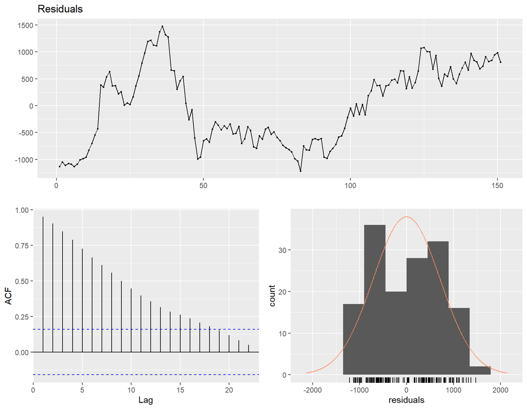

```
##
##  Breusch-Godfrey test for serial correlation of order up to 10
##
## data:  Residuals
## LM test = 138.14, df = 10, p-value < 2.2e-16
```

```r
checkresiduals(model2$model)
```

```r
vif(model2$model)
```

```
##     z.t0     z.t1
## 25.86069 25.86069
```

According to the model summary, all lag weights are significant at 5% level except lag 6 (p-value > 0.05). The adjusted R2 = 17.5% is slightly better than the finite DLM but still very low. The overall significance test reports the model is statistically significant at 5% level.

Diagnostic Checking is not good as there is no random pattern in residuals, it looks like trend, which can be confirmed by decaying pattern in ACF. Breusch-Godfrey test supports serial correlation at 5% of statistical level.

All vif values are above 10 indicating there is high multicollinearity in model.

Hence, model is not a good fit for the given data and can not be further investigated.

## Koyck Distributed Lag Model

```r
model3 = koyckDlm(x = as.vector(ASX_m$copper), y = as.vector(ASX_m$asx))
summary(model3,diagnostics = TRUE)
```

```
##
## Call:
## "Y ~ (Intercept) + Y.1 + X.t"
##
## Residuals:
##     Min      1Q  Median      3Q     Max
## -689.64 -108.62   12.78  140.20  771.79
##
## Coefficients:
##               Estimate Std. Error t value Pr(>|t|)
## (Intercept) 189.368812  87.644648   2.161   0.0322 *
## Y.1           0.971621   0.021895  44.376   <2e-16 ***
## X.t          -0.005864   0.009517  -0.616   0.5387
## ---
## Signif. codes:  0 '***' 0.001 '**' 0.01 '*' 0.05 '.' 0.1 ' ' 1
##
## Residual standard error: 201.9 on 157 degrees of freedom
## Multiple R-Squared: 0.9485,  Adjusted R-squared: 0.9479
## Wald test:  1448 on 2 and 157 DF,  p-value: < 2.2e-16
##
## Diagnostic tests:
##                  df1 df2  statistic      p-value
## Weak instruments   1 157 1966.86799 1.043205e-90
## Wu-Hausman         1 156   10.97528 1.147725e-03
##
##                             alpha         beta       phi
## Geometric coefficients:  6672.885 -0.005863623 0.9716211
```

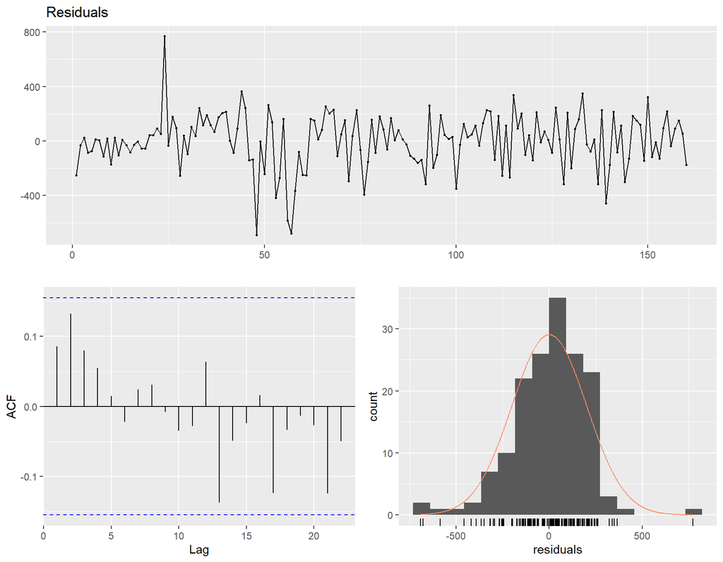

```r
checkresiduals(model3$model)
```

```r
vif(model3$model)
```

```
##      Y.1      X.t
## 1.493966 1.493966
```

From the summary section, it is conclude that X.t (current copper price) is not statistically significant, while Y.t is statistically significant. Overall koycl DLM model is statistically significant with p-value < 0.05. While adjusted R squared is 94.8% which extremely high.

The statistically significant Weak instruments test is indicating that model at the first stage of least-squares estimation is significant. While, statistically significant Wu-Hausman test indicates thatt there is significant correlation between the explanatory variable and the error term.

From the residual diagnostic, it is observed that that the residuals are completely random, fluctuating around mean level and there is no significant lag or pattern in ACF plot. Although, histogram is slightly left skewed.

As vif value is < 10, there is no issue of multi-collinearity.

So far, koyck is best model.

## Autoregressive Distributed Lag Model

The attempt to fit ARDL DLM was taken to find the more appropriate model than Koyck distributed lag model.

The loop was used to find the ardlDLM(p,q) parameters with range of lag lengths. AIC criteria was taken to find the optimal lag order p and q.

```r
for (i in 1:5)
{
  for(j in 1:5)
  {
    model4 = ardlDlm(formula = asx ~ gold + copper, data = data.frame(ASX_m),p = i , q = j )
    cat("p = ", i, "q =" , j,"AIC = ", AIC(model4$model), "BIC = ", BIC(model4$model), "\n")
  }
}
```

```
## p =  1 q = 1 AIC =  2135.427 BIC =  2156.954
## p =  1 q = 2 AIC =  2123.2 BIC =  2147.752
## p =  1 q = 3 AIC =  2108.165 BIC =  2135.728
## p =  1 q = 4 AIC =  2097.165 BIC =  2127.728
## p =  1 q = 5 AIC =  2086.767 BIC =  2120.315
## p =  2 q = 1 AIC =  2119.917 BIC =  2147.537
## p =  2 q = 2 AIC =  2121.523 BIC =  2152.212
## p =  2 q = 3 AIC =  2107.82 BIC =  2141.508
## p =  2 q = 4 AIC =  2096.569 BIC =  2133.244
## p =  2 q = 5 AIC =  2086.252 BIC =  2125.9
## p =  3 q = 1 AIC =  2109.717 BIC =  2143.406
## p =  3 q = 2 AIC =  2110.906 BIC =  2147.657
## p =  3 q = 3 AIC =  2109.982 BIC =  2149.795
## p =  3 q = 4 AIC =  2098.603 BIC =  2141.39
## p =  3 q = 5 AIC =  2088.342 BIC =  2134.09
## p =  4 q = 1 AIC =  2100.046 BIC =  2139.777
## p =  4 q = 2 AIC =  2101.141 BIC =  2143.929
## p =  4 q = 3 AIC =  2100.586 BIC =  2146.43
## p =  4 q = 4 AIC =  2102.043 BIC =  2150.943
## p =  4 q = 5 AIC =  2091.733 BIC =  2143.58
## p =  5 q = 1 AIC =  2089.626 BIC =  2135.374
## p =  5 q = 2 AIC =  2090.472 BIC =  2139.27
## p =  5 q = 3 AIC =  2089.878 BIC =  2141.726
## p =  5 q = 4 AIC =  2091.428 BIC =  2146.326
## p =  5 q = 5 AIC =  2092.86 BIC =  2150.807
```

From AIC, following parameters were taken.

ardlDLM(1,5)

ardlDLM(2,5)

ardlDLM(3,5),

All three models were investigated.

**ardlDLM(1,5)**

```r
model4_1 = ardlDlm(formula = asx ~ gold + copper, data = data.frame(ASX_m), p = 1 , q = 5)
summary(model4_1)
```

```
##
## Time series regression with "ts" data:
## Start = 6, End = 161
##
## Call:
## dynlm(formula = as.formula(model.text), data = data)
##
## Residuals:
##     Min      1Q  Median      3Q     Max
## -608.69 -108.99   -1.87   96.72  697.71
##
## Coefficients:
##               Estimate Std. Error t value Pr(>|t|)
## (Intercept) 204.195354  91.833430   2.224 0.027715 *
## gold.t       -1.168101   0.298139  -3.918 0.000137 ***
## gold.1        1.175789   0.293809   4.002 9.96e-05 ***
## copper.t      0.094982   0.032049   2.964 0.003551 **
## copper.1     -0.096433   0.032189  -2.996 0.003216 **
## asx.1         0.932523   0.078420  11.891  < 2e-16 ***
## asx.2         0.184956   0.111691   1.656 0.099876 .
## asx.3        -0.094300   0.109515  -0.861 0.390613
## asx.4        -0.063908   0.109287  -0.585 0.559605
## asx.5         0.002755   0.077303   0.036 0.971618
## ---
## Signif. codes:  0 '***' 0.001 '**' 0.01 '*' 0.05 '.' 0.1 ' ' 1
##
## Residual standard error: 187.2 on 146 degrees of freedom
## Multiple R-squared:  0.9531, Adjusted R-squared:  0.9502
## F-statistic: 329.5 on 9 and 146 DF,  p-value: < 2.2e-16
```

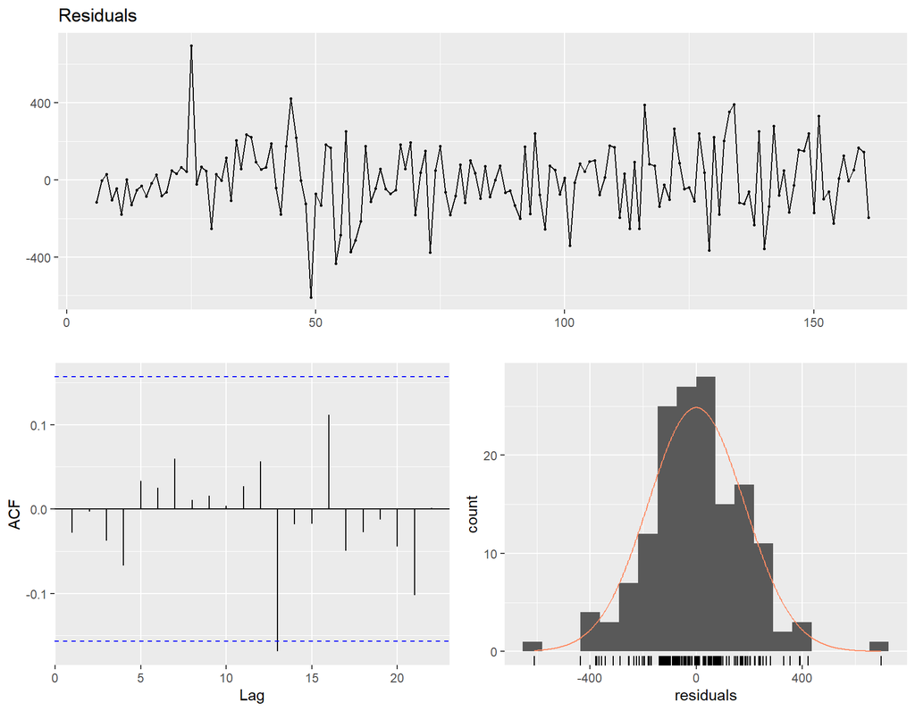

```
##
##  Breusch-Godfrey test for serial correlation of order up to 13
##
## data:  Residuals
## LM test = 11.315, df = 13, p-value = 0.5844
```

```r
checkresiduals(model4_1$model)
```

```r
vif(model4_1$model)
```

```
##         gold   L(gold, 1)       copper L(copper, 1)    L(asx, 1)    L(asx, 2)
##     60.17390     59.02863     18.45786     19.20054     19.61994     40.62230
##    L(asx, 3)    L(asx, 4)    L(asx, 5)
##     39.99994     40.92965     20.93150
```

**ardlDLM(2,5)**

```r
model4_2 = ardlDlm(formula = asx ~ gold + copper, data = data.frame(ASX_m), p = 2 , q = 5)
summary(model4_2)
```

```
##
## Time series regression with "ts" data:
## Start = 6, End = 161
##
## Call:
## dynlm(formula = as.formula(model.text), data = data)
##
## Residuals:
##     Min      1Q  Median      3Q     Max
## -590.34 -108.63    0.29   93.85  705.46
##
## Coefficients:
##               Estimate Std. Error t value Pr(>|t|)
## (Intercept)  1.953e+02  9.127e+01   2.139 0.034081 *
## gold.t      -1.148e+00  2.966e-01  -3.868 0.000165 ***
## gold.1       1.270e+00  4.357e-01   2.915 0.004131 **
## gold.2      -1.007e-01  3.081e-01  -0.327 0.744282
## copper.t     7.565e-02  3.355e-02   2.255 0.025665 *
## copper.1    -1.200e-02  5.335e-02  -0.225 0.822345
## copper.2    -6.907e-02  3.449e-02  -2.003 0.047097 *
## asx.1        9.092e-01  8.324e-02  10.923  < 2e-16 ***
## asx.2        1.866e-01  1.113e-01   1.677 0.095794 .
## asx.3       -5.901e-02  1.129e-01  -0.523 0.601953
## asx.4       -7.267e-02  1.087e-01  -0.668 0.505049
## asx.5        9.629e-04  7.673e-02   0.013 0.990005
## ---
## Signif. codes:  0 '***' 0.001 '**' 0.01 '*' 0.05 '.' 0.1 ' ' 1
##
## Residual standard error: 185.8 on 144 degrees of freedom
## Multiple R-squared:  0.9544, Adjusted R-squared:  0.9509
## F-statistic: 274.1 on 11 and 144 DF,  p-value: < 2.2e-16
```

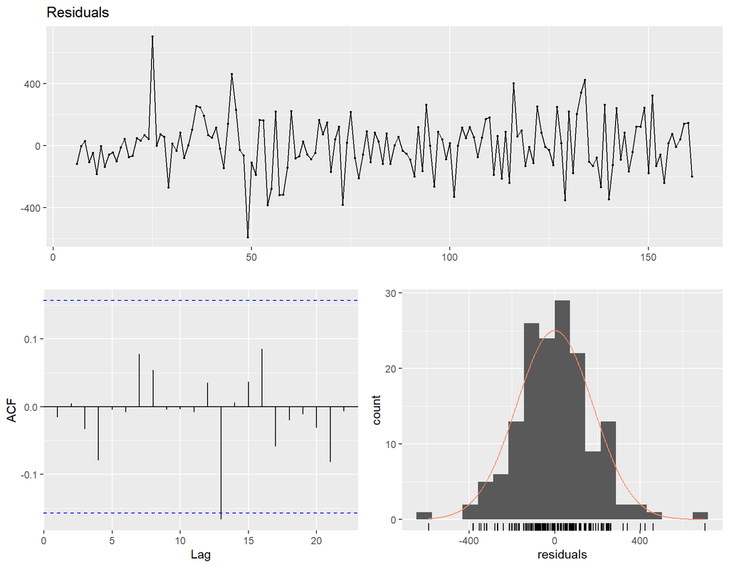

```
##
##  Breusch-Godfrey test for serial correlation of order up to 15
##
## data:  Residuals
## LM test = 14.041, df = 15, p-value = 0.5224
```

```r
checkresiduals(model4_2$model)
```

```r
vif(model4_2$model)
```

```
##         gold   L(gold, 1)   L(gold, 2)       copper L(copper, 1) L(copper, 2)
##     60.48199    131.76923     66.52833     20.53927     53.54225     23.07222
##    L(asx, 1)    L(asx, 2)    L(asx, 3)    L(asx, 4)    L(asx, 5)
##     22.44197     40.96126     43.14764     41.14631     20.93494
```

**ardlDLM(3,5)**

```r
model4_3 = ardlDlm(formula = asx ~ gold + copper, data = data.frame(ASX_m), p = 3 , q = 5)
summary(model4_3)
```

```
##
## Time series regression with "ts" data:
## Start = 6, End = 161
##
## Call:
## dynlm(formula = as.formula(model.text), data = data)
##
## Residuals:
##     Min      1Q  Median      3Q     Max
## -579.26 -106.14   -3.19  100.67  708.25
##
## Coefficients:
##               Estimate Std. Error t value Pr(>|t|)
## (Intercept) 192.817278  91.367906   2.110 0.036582 *
## gold.t       -1.078264   0.301502  -3.576 0.000477 ***
## gold.1        1.170990   0.442628   2.646 0.009075 **
## gold.2        0.245783   0.458093   0.537 0.592429
## gold.3       -0.308971   0.313521  -0.985 0.326060
## copper.t      0.072304   0.033677   2.147 0.033495 *
## copper.1     -0.011834   0.054183  -0.218 0.827427
## copper.2     -0.038084   0.054057  -0.705 0.482270
## copper.3     -0.029416   0.035206  -0.836 0.404817
## asx.1         0.896281   0.084295  10.633  < 2e-16 ***
## asx.2         0.207550   0.114437   1.814 0.071841 .
## asx.3        -0.060117   0.113402  -0.530 0.596856
## asx.4        -0.076059   0.112909  -0.674 0.501638
## asx.5        -0.002674   0.077384  -0.035 0.972480
## ---
## Signif. codes:  0 '***' 0.001 '**' 0.01 '*' 0.05 '.' 0.1 ' ' 1
##
## Residual standard error: 185.9 on 142 degrees of freedom
## Multiple R-squared:  0.955,  Adjusted R-squared:  0.9509
## F-statistic: 231.7 on 13 and 142 DF,  p-value: < 2.2e-16
```

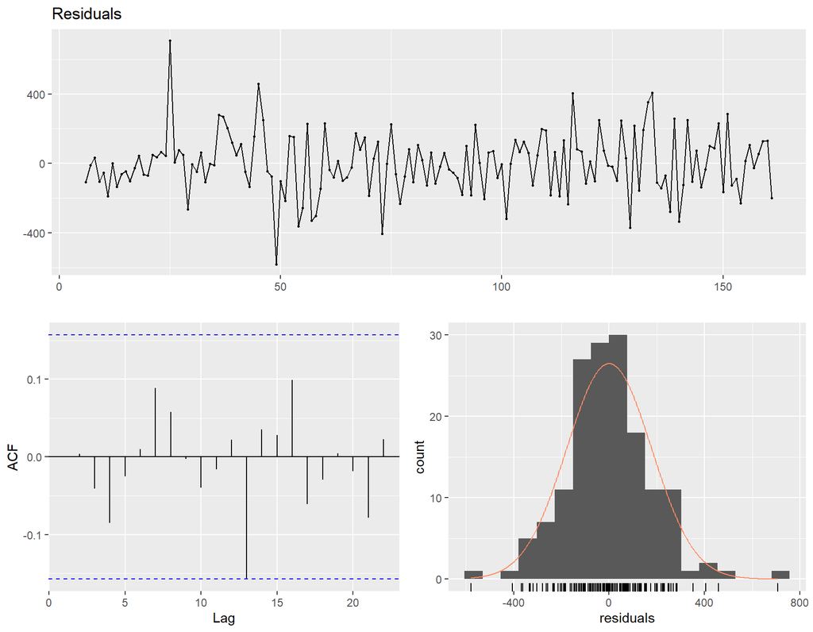

```
##
##  Breusch-Godfrey test for serial correlation of order up to 17
##
## data:  Residuals
## LM test = 15.848, df = 17, p-value = 0.5346
```

```r
checkresiduals(model4_3$model)
```

```r
vif(model4_3$model)
```

```
##         gold   L(gold, 1)   L(gold, 2)   L(gold, 3)       copper L(copper, 1)
##     62.36987    135.77906    146.83595     69.45807     20.65614     55.13933
## L(copper, 2) L(copper, 3)    L(asx, 1)    L(asx, 2)    L(asx, 3)    L(asx, 4)
##     56.58181     24.69407     22.97584     43.22008     43.46897     44.27681
##    L(asx, 5)
##     21.25863
```

There is high multicollinearity as all the vif values are above 10.

Hence, all these models are can not be further investigated.

# Conclusion

The analysis of dataset was started by exploring the visualisation, every series in the dataset was explored seperately before analyse relationship between them was taken. There was clear indication of intervention point in the year 2008, however, gold price did not suffer with financial crisis in 2008. Correlation gave indication that ASX all ordinaries price index is having slightly to moderate correlation with copper price.

By analysing time-sereis plots, ACF - PACF plots and unit root tests, there was clear indication of non-stationarity in the dataest, which was then handled by BOX-COX transformation and taking 1st order difference.

Then analysis of decomposition was taken. The STL plot, x12 plot were analysed and since, there was no clear indication of seasonal effcet on the dataset, conclusion was made that series is all about trend and there are other external factors influencing the ASX all ordinaries price index.

Then, attempt to find most accurate and suitable distributed model fpr ASX all ordinaries price index was taken. After fitting Finite DLM model and ARDL model with ASX = gold + copper, and kyock and polynomial dlm model with ASX = copper, conclusion was made that most suitable model is **Koyck Distributed Lag Model**. As it has good diagnostics, great level of adjusted r squared, no multi-collinearity problem and high explainability.

In nutshell, Koyck Distributed Lag Model is most accurate and suitable model for further forecasting for the given dataset.

# Reference

Class Lectures - Labs (module 1 - 3)